# Patterns in the Juan Fernandez fur seal faecal microbiome: R script 2

Constanza Toro

This is script number 2 of a series of html files containing all the code used for the statistical analysis of "Patterns in the Juan Fernandez fur seal (Arctophoca philippii philippii) faecal microbiome". The direct outputs of this analysis were the object generated with Script 1 located in the R_code folder within this [GitHub repository](https://github.com/Cotissima/JFFS_microbiome_first_characterisation). This script aims to look at differences in three alpha diversity estimators (Chao 1, Shannon-Weiner and Simpson) between the locations from which samples were collected.

This script includes the full alpha diversity analysis:  
*Note: files needed to run this coded were generated in section 3 of Script 1*  
1. Chao1  
1.1. Full data  
1.2. Core data  
2. Shannon-Weiner  
2.1. Full data  
2.2. Core data  
3. Simpson  
3.1. Full data  
3.2. Core data 4 Final visualisation

- Load libraries

```r
library(rstatix)
library(tidyverse)
library(DescTools)
```

- Load metadata  
  *Note: using non-normalised data*

```r
# Full meta
read.csv("F2meta.csv") -> JFFS.meta

JFFS.meta$Year <- as.factor(JFFS.meta$Year)

# Core meta
read.csv("F2coremeta.csv") -> coremeta

coremeta$Year <- as.factor(coremeta$Year)
```

- Data clean-up Locations with only one sample will be removed from this analysis

```r
# Full meta
JFFS.meta %>%
  filter(Location != "vaqueria",
         Location != "piedra_carvajal",
         Location != "pta_trueno") -> JFFS.metaF

# Core meta
coremeta %>%
  filter(Location != "vaqueria",
         Location != "piedra_carvajal",
         Location != "pta_trueno") -> coremetaF
```

# 1 Chao 1

## 1.1 Full data

- Descriptive stats summary, Chao 1

```r
JFFS.metaF %>%
  group_by(Location) %>%
  get_summary_stats(Chao1, type = "mean_sd") %>%
  ungroup()
```

```
## # A tibble: 4 x 5
##   Location        variable     n  mean    sd
##   <fct>           <chr>    <dbl> <dbl> <dbl>
## 1 arenal          Chao1        8  72.6  23.0
## 2 bahia_padre     Chao1       22  75.7  27.4
## 3 santa_clara     Chao1       12  68.2  30.0
## 4 tierras_blancas Chao1        9 102.   40.2
```

**Figure 1:** Exloratory boxplot

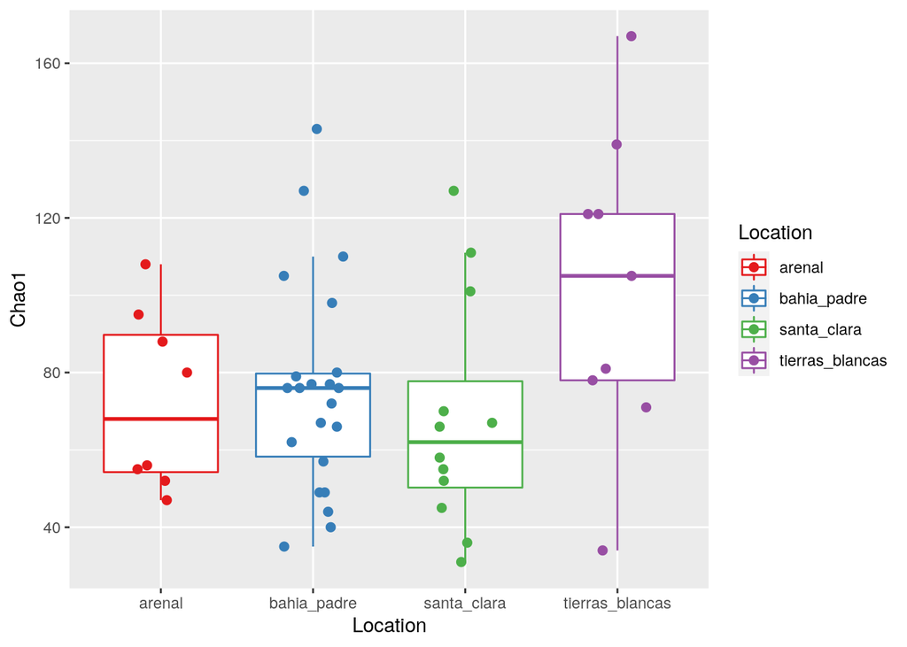

```r
JFFS.metaF %>%
  ggplot(aes(x=Location,
             y=Chao1,
             colour = Location)) +
  geom_boxplot(outlier.shape = NA) +
  geom_jitter(height = 0, size = 2, width = 0.2) +
  scale_colour_brewer(palette = "Set1")
```

**Figure 2:** Exloratory qqplot

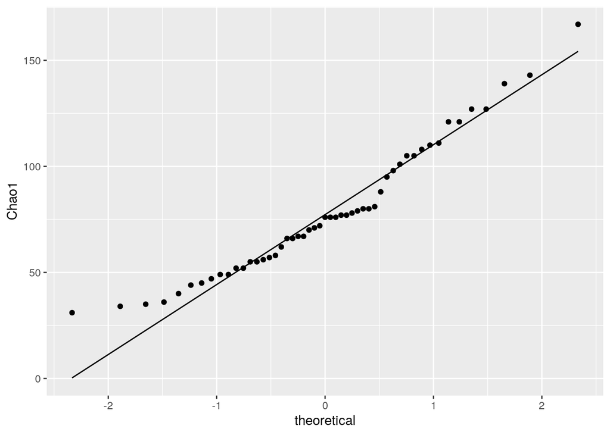

```r
JFFS.metaF %>%
  ggplot(aes(sample = Chao1)) +
  stat_qq() +
  stat_qq_line() +
  ylab("Chao1")
```

**Figure 3:** Exloratory qqplot per location

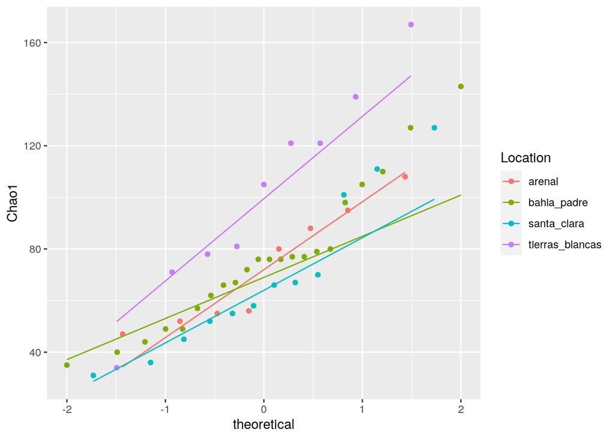

```r
JFFS.metaF %>%
  ggplot(aes(sample = Chao1, colour=Location)) +
  stat_qq() +
  stat_qq_line() +
  ylab("Chao1")
```

- Anova

```r
fit.Chao1 <- lm(Chao1~Location, data=JFFS.metaF)
summary(fit.Chao1)
```

```
##
## Call:
## lm(formula = Chao1 ~ Location, data = JFFS.metaF)
##
## Residuals:
##    Min     1Q Median     3Q    Max
## -67.89 -20.76  -1.25  19.11  67.32
##
## Coefficients:
##                         Estimate Std. Error t value Pr(>|t|)
## (Intercept)               72.625     10.609   6.845  1.4e-08 ***
## Locationbahia_padre        3.057     12.389   0.247   0.8062
## Locationsanta_clara       -4.375     13.697  -0.319   0.7508
## Locationtierras_blancas   29.264     14.581   2.007   0.0505 .
## ---
## Signif. codes:  0 '***' 0.001 '**' 0.01 '*' 0.05 '.' 0.1 ' ' 1
##
## Residual standard error: 30.01 on 47 degrees of freedom
## Multiple R-squared:  0.1354, Adjusted R-squared:  0.08018
## F-statistic: 2.453 on 3 and 47 DF,  p-value: 0.07491
```

No significant difference between locations when looking at Chao 1.

- Checking assumption: Shapiro test

```r
JFFS.metaF %>%
  group_by(Location) %>%
  shapiro_test(Chao1)
```

```
## # A tibble: 4 x 4
##   Location        variable statistic     p
##   <fct>           <chr>        <dbl> <dbl>
## 1 arenal          Chao1        0.895 0.261
## 2 bahia_padre     Chao1        0.935 0.159
## 3 santa_clara     Chao1        0.911 0.220
## 4 tierras_blancas Chao1        0.982 0.974
```

Normality assumption was met

- Checking assumption: Levene's test

```r
JFFS.metaF %>%
  levene_test(Chao1 ~ Location)
```

```
## # A tibble: 1 x 4
##     df1   df2 statistic     p
##   <int> <int>     <dbl> <dbl>
## 1     3    47     0.919 0.439
```

Heteroscedaticity assumption was met

- Looking for outliers Check for residuals. *Values with standardised residual > 3 will be considered outliers.*

```r
rstandard(fit.Chao1) -> st.residual.Chao1
st.residual.Chao1
```

```
##           1           2           3           4           5           6
## -0.46667275  0.01085285  0.01085285 -0.91008938 -0.33023686 -1.38761498
##           7           8           9          10          11          12
##  1.75041041  1.00001303  0.10996607  0.67550588  0.01085285 -0.73834363
##          13          14          15          16          17          18
##  1.31173815  2.30143281  2.29615395  0.67550588  1.26025768  0.04496183
##          19          20          21          22          23          24
## -0.63721761  0.04496183 -0.91008938 -0.12558303  0.11317977 -0.29612789
##          25          26          27          28          29          30
## -2.39961680 -0.73477922 -0.62790224 -0.91290751  0.54774451  0.26273923
##          31          32          33          34          35          36
##  0.14728874 -1.08063424  2.04488592  0.06091150 -0.84438234 -0.46118704
##          37          38          39          40          41          42
## -0.07831478 -1.29654469  1.48798082 -1.12251184 -0.35676733 -0.04350821
##          43          44          45          46          47          48
## -0.80925272 -1.09180601 -0.56560674  1.13991513 -1.21707012  1.17055789
##          49          50          51
##  0.76125023  0.79712412 -0.59227658
```

No outliers

## 1.2 Core Data

- Descriptive stats summary, Chao 1

```r
coremetaF %>%
  group_by(Location) %>%
  get_summary_stats(Chao1, type = "mean_sd") %>%
  ungroup()
```

```
## # A tibble: 4 x 5
##   Location        variable     n  mean    sd
##   <fct>           <chr>    <dbl> <dbl> <dbl>
## 1 arenal          Chao1        8  34.4  4.27
## 2 bahia_padre     Chao1       22  33.6  6.09
## 3 santa_clara     Chao1       12  31.7  5.90
## 4 tierras_blancas Chao1        9  37.4  6.33
```

**Figure 4:** Exploratory boxplot

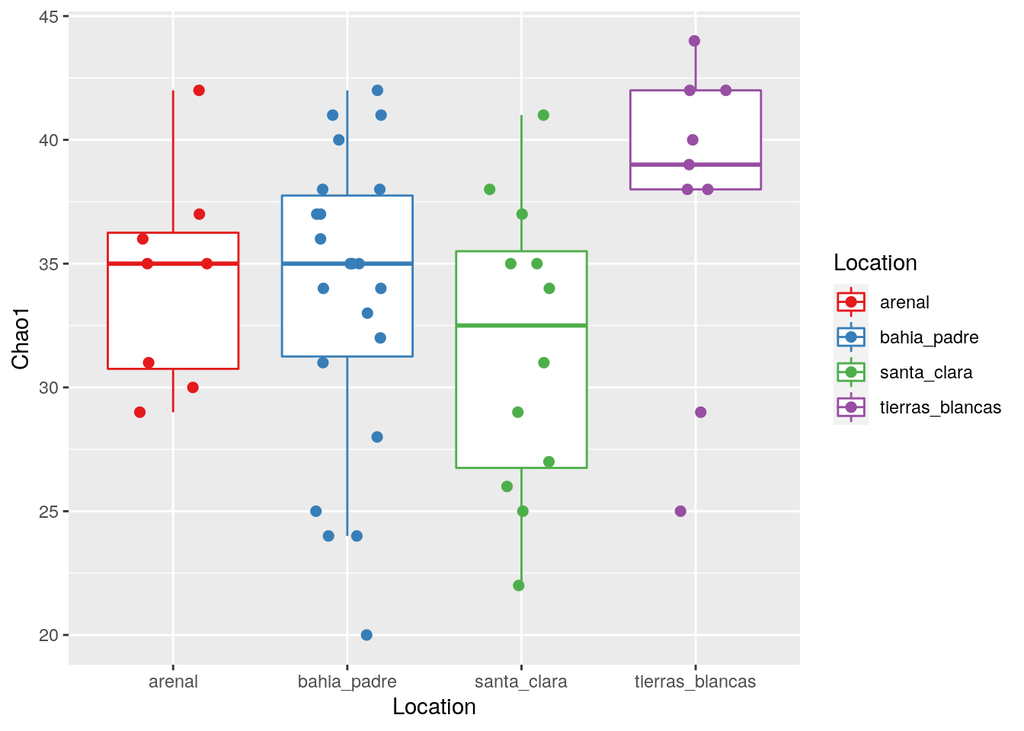

```r
coremetaF %>%
  ggplot(aes(x=Location, y=Chao1, colour = Location)) +
  geom_boxplot(outlier.shape = NA) +
  geom_jitter(height = 0, size = 2, width = 0.2) +
  scale_colour_brewer(palette = "Set1")
```

**Figure 5:** Exploratory qqplot

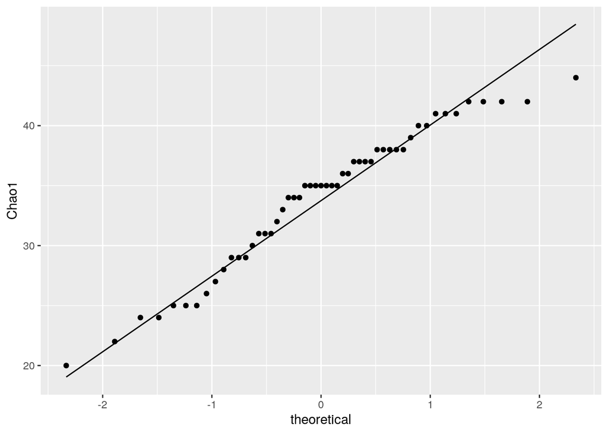

```r
coremetaF %>%
  ggplot(aes(sample = Chao1)) +
  stat_qq() +
  stat_qq_line() +
  ylab("Chao1")
```

**Figure 6:** Exploratory qqplot location

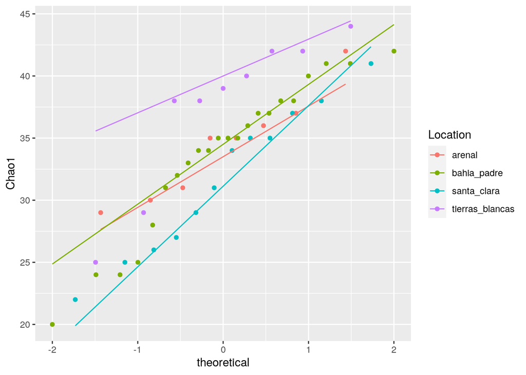

```r
coremetaF %>%
  ggplot(aes(sample = Chao1, colour=Location)) +
  stat_qq() +
  stat_qq_line() +
  ylab("Chao1")
```

- Anova

```r
fit.Chao1 <- lm(Chao1~Location, data=coremetaF)
summary(fit.Chao1)
```

```
##
## Call:
## lm(formula = Chao1 ~ Location, data = coremetaF)
##
## Residuals:
##     Min      1Q  Median      3Q     Max
## -13.636  -3.875   1.364   3.864   9.333
##
## Coefficients:
##                         Estimate Std. Error t value Pr(>|t|)
## (Intercept)              34.3750     2.0692  16.613   <2e-16 ***
## Locationbahia_padre      -0.7386     2.4163  -0.306    0.761
## Locationsanta_clara      -2.7083     2.6713  -1.014    0.316
## Locationtierras_blancas   3.0694     2.8438   1.079    0.286
## ---
## Signif. codes:  0 '***' 0.001 '**' 0.01 '*' 0.05 '.' 0.1 ' ' 1
##
## Residual standard error: 5.853 on 47 degrees of freedom
## Multiple R-squared:  0.09859,    Adjusted R-squared:  0.04105
## F-statistic: 1.713 on 3 and 47 DF,  p-value: 0.1771
```

No significant difference.

- Checking assumption: Shapiro test

```r
coremetaF %>%
  group_by(Location) %>%
  shapiro_test(Chao1)
```

```
## # A tibble: 4 x 4
##   Location        variable statistic      p
##   <fct>           <chr>        <dbl>  <dbl>
## 1 arenal          Chao1        0.939 0.597
## 2 bahia_padre     Chao1        0.928 0.109
## 3 santa_clara     Chao1        0.965 0.858
## 4 tierras_blancas Chao1        0.838 0.0551
```

Normality assumption was met.

- Checking assumption: Levene's test

```r
coremetaF %>%
  levene_test(Chao1 ~ Location)
```

```
## # A tibble: 1 x 4
##     df1   df2 statistic     p
##   <int> <int>     <dbl> <dbl>
## 1     3    47     0.409 0.747
```

Heteroscedaticity assumption was met.

- Looking for outliers. Check for residuals. *Values with standardised residual > 3 will be considered outliers.*

```r
rstandard(fit.Chao1) -> st.residual.Chao1
st.residual.Chao1
```

```
##           1           2           3           4           5           6
##  0.23848213  0.58825592  0.76314282 -1.68527372 -0.98572614 -2.38482130
##           7           8           9          10          11          12
##  0.06359523  0.76314282  0.10068374  0.46314520  0.23848213  0.10068374
##          13          14          15          16          17          18
##  1.18806811  0.82560665  1.46269040  0.82560665  1.39280846  0.58825592
##          19          20          21          22          23          24
## -0.11129166  0.06359523 -0.46106545  0.41336903 -0.28617856  0.23848213
##          25          26          27          28          29          30
## -2.25531574 -0.79915240 -0.61648899  0.11416463  0.29682803  0.47949144
##          31          32          33          34          35          36
##  1.11291661 -1.51038683  0.59487895  1.13027001  0.28191447 -0.11897579
##          37          38          39          40          41          42
## -0.47590316 -1.72514896  1.66566106 -1.01129422  0.41641527  0.59487895
##          43          44          45          46          47          48
## -1.18975790 -1.53039282 -0.83283053  0.95180632 -1.68527372  1.28780350
##          49          50          51
##  1.28780350  0.11416463 -0.98181580
```

No outliers  
The trend observed when using the core dataset were very similar to the ones identified in the full data.

# 2 Shannon-Weiner

## 2.1 Full data

- Descriptive stats summary, Shannon-Weiner

```r
JFFS.metaF %>%
  group_by(Location) %>%
  get_summary_stats(Shannon, type = "mean_sd") %>%
  ungroup()
```

```
## # A tibble: 4 x 5
##   Location        variable     n  mean    sd
##   <fct>           <chr>    <dbl> <dbl> <dbl>
## 1 arenal          Shannon      8  2.89 0.543
## 2 bahia_padre     Shannon     22  2.88 0.483
## 3 santa_clara     Shannon     12  2.77 0.746
## 4 tierras_blancas Shannon      9  3.39 0.365
```

**Figure 7:** Exloratory boxplot

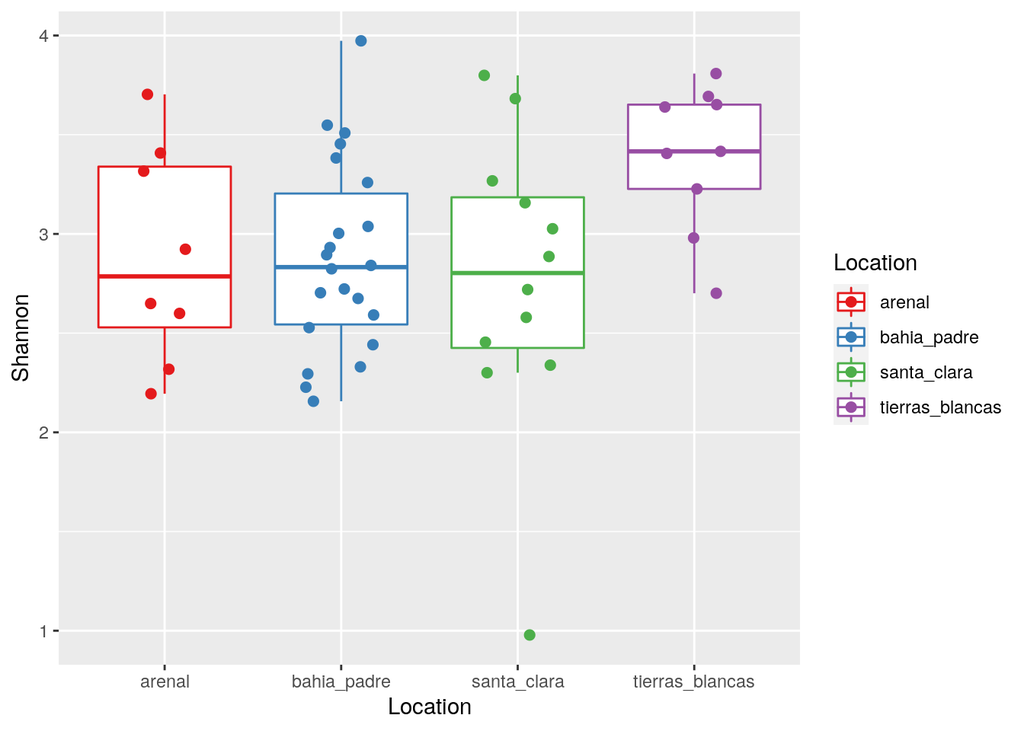

```r
JFFS.metaF %>%
  ggplot(aes(x=Location, y=Shannon, colour = Location)) +
  geom_boxplot(outlier.shape = NA) +
  geom_jitter(height = 0, size = 2, width = 0.2) +
  scale_colour_brewer(palette = "Set1")
```

**Figure 8:** Exloratory qqplot

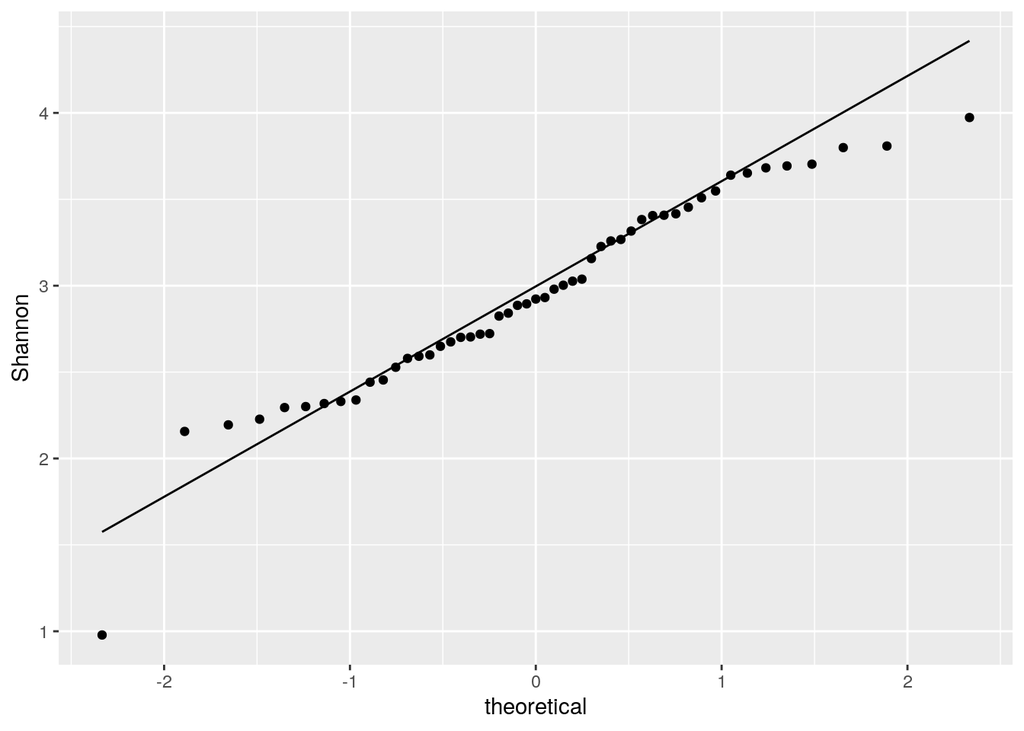

```r
JFFS.metaF %>%
  ggplot(aes(sample = Shannon)) +
  stat_qq() +
  stat_qq_line() +
  ylab("Shannon")
```

**Figure 9:** Exloratory qqplot per location

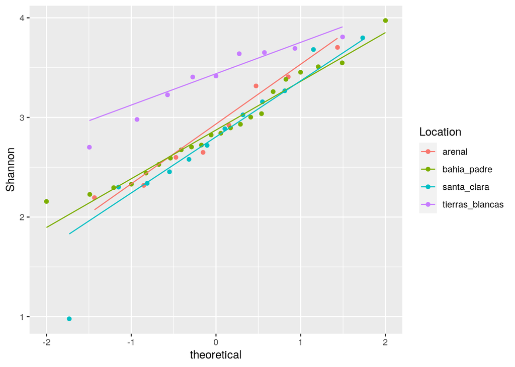

```r
JFFS.metaF %>%
  ggplot(aes(sample = Shannon, colour=Location)) +
  stat_qq() +
  stat_qq_line() +
  ylab("Shannon")
```

- Anova

```r
fit.Shannon <- lm(Shannon~Location, data=JFFS.metaF)
summary(fit.Shannon)
```

```
##
## Call:
## lm(formula = Shannon ~ Location, data = JFFS.metaF)
##
## Residuals:
##      Min       1Q   Median       3Q      Max
## -1.78723 -0.33106  0.01446  0.38587  1.09466
##
## Coefficients:
##                         Estimate Std. Error t value Pr(>|t|)
## (Intercept)              2.88890    0.19404  14.888   <2e-16 ***
## Locationbahia_padre     -0.01036    0.22659  -0.046   0.9637
## Locationsanta_clara     -0.12320    0.25051  -0.492   0.6252
## Locationtierras_blancas  0.50247    0.26669   1.884   0.0657 .
## ---
## Signif. codes:  0 '***' 0.001 '**' 0.01 '*' 0.05 '.' 0.1 ' ' 1
##
## Residual standard error: 0.5488 on 47 degrees of freedom
## Multiple R-squared:  0.1398, Adjusted R-squared:  0.08492
## F-statistic: 2.547 on 3 and 47 DF,  p-value: 0.06719
```

- Checking assumption: Shapiro test

```r
JFFS.metaF %>%
  group_by(Location) %>%
  shapiro_test(Shannon)
```

```
## # A tibble: 4 x 4
##   Location        variable statistic     p
##   <fct>           <chr>        <dbl> <dbl>
## 1 arenal          Shannon      0.947 0.680
## 2 bahia_padre     Shannon      0.964 0.575
## 3 santa_clara     Shannon      0.925 0.329
## 4 tierras_blancas Shannon      0.917 0.366
```

Normality assumption was met

- Checking assumption: Levene's test

```r
JFFS.metaF %>%
  levene_test(Shannon ~ Location)
```

```
## # A tibble: 1 x 4
##     df1   df2 statistic     p
##   <int> <int>     <dbl> <dbl>
## 1     3    47      1.13 0.345
```

Heteroscedaticity assumption was met

- Looking for outliers. *Values with standardised residual > 3 will be considered outliers.* Check for residuals

```r
rstandard(fit.Shannon) -> st.residual.Shannon
st.residual.Shannon
```

```
##           1           2           3           4           5           6
## -0.29074117  0.09862179 -1.08876632 -1.02299411  0.70945569 -0.81498891
##           7           8           9          10          11          12
##  2.04143871  0.94034120  0.02793860  0.58295717  0.23161796 -0.79535370
##          13          14          15          16          17          18
##  0.47984167  0.80567585  1.24866947  0.50314355  1.58640028  0.29703343
##          19          20          21          22          23          24
## -1.34647224  0.03043587 -1.21443682 -0.10147028 -0.06973726 -0.65409936
##          25          26          27          28          29          30
## -1.33416661  0.06596464 -0.46682108 -1.35245787  0.83243731 -0.56400670
##          31          32          33          34          35          36
## -0.38009877 -0.32671071  1.96671958  0.22932704  0.04779427 -0.08788519
##          37          38          39          40          41          42
##  0.74471134 -3.40119138  1.74356046 -0.59258151  0.49554367 -0.35476847
##          43          44          45          46          47          48
## -0.88540234 -0.31783081 -0.81304073  0.95500754 -0.53530052  1.17539661
##          49          50          51
##  1.07280573  1.01060104 -1.11211761
```

One outlier was found (Sample 18JFFS23/possition 38).

Sample removal

```r
JFFS.metaF %>%
  add_column(st.residual.Shannon) %>%
  filter(abs(st.residual.Shannon) < 3) -> JFFS.metaFclean
```

- Anova (clean data)

```r
fit.Shannon <- lm(Shannon~Location, data=JFFS.metaFclean)
summary(fit.Shannon)
```

```
##
## Call:
## lm(formula = Shannon ~ Location, data = JFFS.metaFclean)
##
## Residuals:
##      Min       1Q   Median       3Q      Max
## -0.72201 -0.35028 -0.01147  0.32993  1.09466
##
## Coefficients:
##                         Estimate Std. Error t value Pr(>|t|)
## (Intercept)              2.88890    0.17030  16.963   <2e-16 ***
## Locationbahia_padre     -0.01036    0.19887  -0.052   0.9587
## Locationsanta_clara      0.03928    0.22382   0.175   0.8615
## Locationtierras_blancas  0.50247    0.23406   2.147   0.0371 *
## ---
## Signif. codes:  0 '***' 0.001 '**' 0.01 '*' 0.05 '.' 0.1 ' ' 1
##
## Residual standard error: 0.4817 on 46 degrees of freedom
## Multiple R-squared:  0.1474, Adjusted R-squared:  0.09177
## F-statistic:  2.65 on 3 and 46 DF,  p-value: 0.05986
```

No significant difference between locations when looking at Shannon-Weiner. However the trend seems consistent and the p value was marginally significant.  
- Re-checking assumption: Shapiro test

```r
JFFS.metaFclean %>%
  group_by(Location) %>%
  shapiro_test(Shannon)
```

```
## # A tibble: 4 x 4
##   Location        variable statistic     p
##   <fct>           <chr>        <dbl> <dbl>
## 1 arenal          Shannon      0.947 0.680
## 2 bahia_padre     Shannon      0.964 0.575
## 3 santa_clara     Shannon      0.938 0.495
## 4 tierras_blancas Shannon      0.917 0.366
```

Normality assumption was met

- Re-checking assumption: Levene's test

```r
JFFS.metaFclean %>%
  levene_test(Shannon ~ Location)
```

```
## # A tibble: 1 x 4
##     df1   df2 statistic     p
##   <int> <int>     <dbl> <dbl>
## 1     3    46     0.647 0.589
```

Heteroscedasticity assumption was met

- post hoc test

```r
DunnettTest(Shannon ~ factor(Location),
            control="tierras_blancas",
            data = JFFS.metaFclean)
```

```
##
##   Dunnett's test for comparing several treatments with a control :
##     95% family-wise confidence level
##
## $tierras_blancas
##                                   diff     lwr.ci      upr.ci   pval
## arenal-tierras_blancas      -0.5024700 -1.0670221  0.06208217 0.0903 .
## bahia_padre-tierras_blancas -0.5128256 -0.9725463 -0.05310485 0.0254 *
## santa_clara-tierras_blancas -0.4631906 -0.9853983  0.05901706 0.0915 .
##
## ---
## Signif. codes:  0 '***' 0.001 '**' 0.01 '*' 0.05 '.' 0.1 ' ' 1
```

Tierras Blancas was significantly different from Bahia El Padre and the difference between TB and the other to locations was marginally significant. The low sampling size might explain the high p values.

## 2.2 Core Data

```r
coremetaF %>%
  group_by(Location) %>%
  get_summary_stats(Shannon, type = "mean_sd") %>%
  ungroup()
```

```
## # A tibble: 4 x 5
##   Location        variable     n  mean    sd
##   <fct>           <chr>    <dbl> <dbl> <dbl>
## 1 arenal          Shannon      8  2.44 0.411
## 2 bahia_padre     Shannon     22  2.38 0.35
## 3 santa_clara     Shannon     12  2.29 0.603
## 4 tierras_blancas Shannon      9  2.76 0.165
```

**Figure 10:** Exploratory boxplot

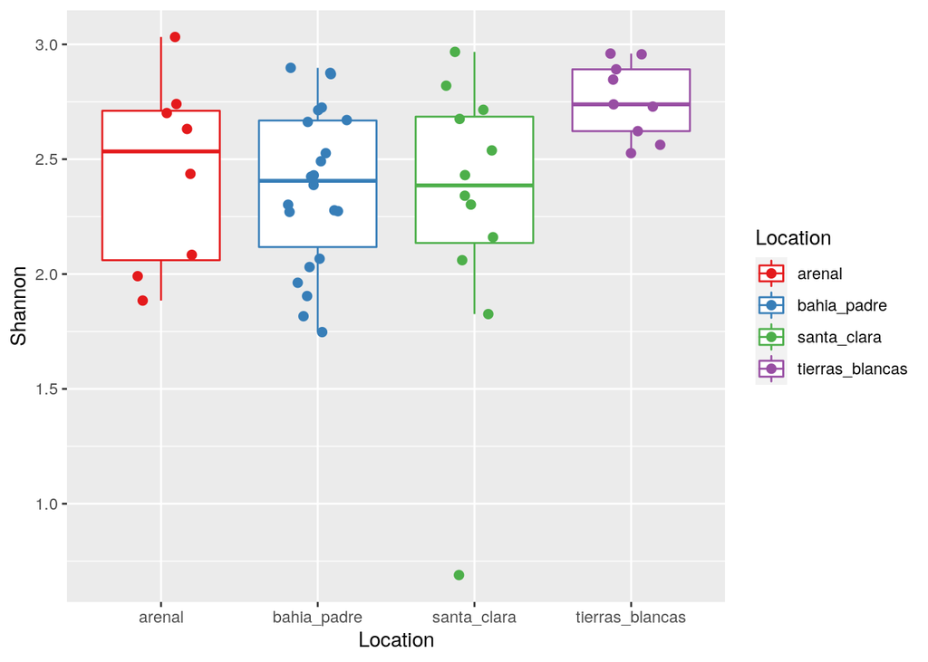

```r
coremetaF %>%
  ggplot(aes(x=Location, y=Shannon, colour = Location)) +
  geom_boxplot(outlier.shape = NA) +
  geom_jitter(height = 0, size = 2, width = 0.2) +
  scale_colour_brewer(palette = "Set1")
```

**Figure 11:** Exploratory qqplot

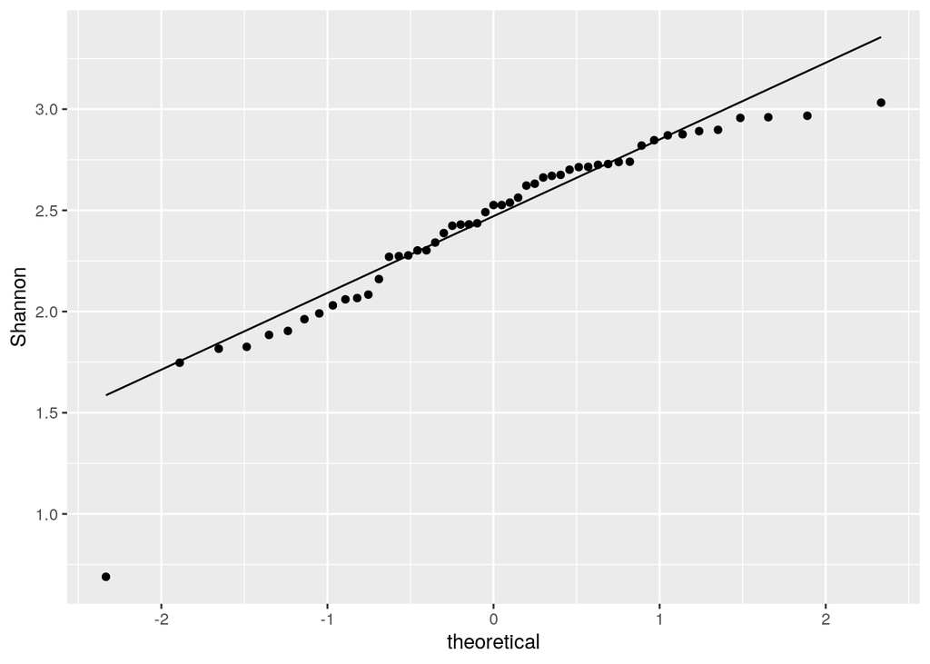

```r
coremetaF %>%
  ggplot(aes(sample = Shannon)) +
  stat_qq() +
  stat_qq_line() +
  ylab("Shannon")
```

**Figure 12:** Exploratory qqplot location

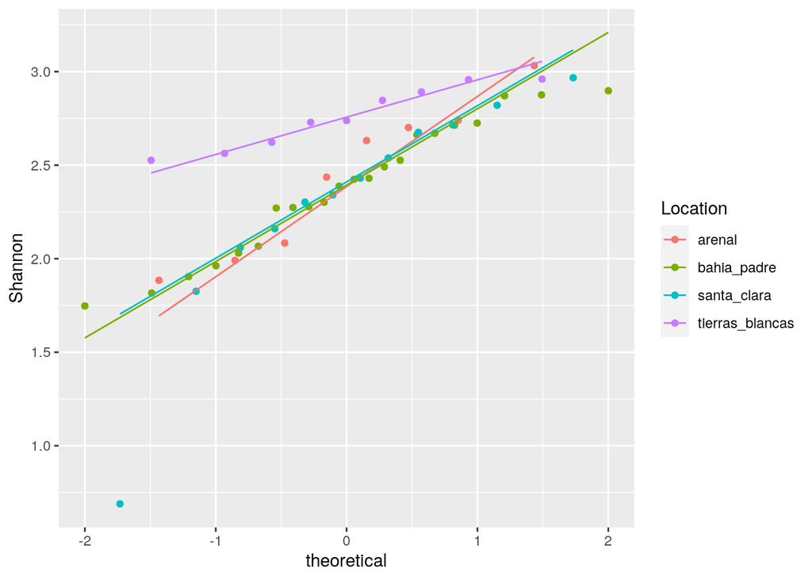

```r
coremetaF %>%
  ggplot(aes(sample = Shannon, colour=Location)) +
  stat_qq() +
  stat_qq_line() +
  ylab("Shannon")
```

- Anova

```r
fit.Shannon <- lm(Shannon~Location, data=coremetaF)
summary(fit.Shannon)
```

```
##
## Call:
## lm(formula = Shannon ~ Location, data = coremetaF)
##
## Residuals:
##      Min       1Q   Median       3Q      Max
## -1.60429 -0.21480  0.04553  0.27370  0.67344
##
## Coefficients:
##                         Estimate Std. Error t value Pr(>|t|)
## (Intercept)              2.43750    0.14555  16.747   <2e-16 ***
## Locationbahia_padre     -0.05911    0.16997  -0.348    0.730
## Locationsanta_clara     -0.14369    0.18791  -0.765    0.448
## Locationtierras_blancas  0.32179    0.20004   1.609    0.114
## ---
## Signif. codes:  0 '***' 0.001 '**' 0.01 '*' 0.05 '.' 0.1 ' ' 1
##
## Residual standard error: 0.4117 on 47 degrees of freedom
## Multiple R-squared:  0.1362, Adjusted R-squared:  0.08109
## F-statistic: 2.471 on 3 and 47 DF,  p-value: 0.07337
```

- Checking assumption: Shapiro test

```r
coremetaF %>%
  group_by(Location) %>%
  shapiro_test(Shannon)
```

```
## # A tibble: 4 x 4
##   Location        variable statistic      p
##   <fct>           <chr>        <dbl>  <dbl>
## 1 arenal          Shannon      0.933 0.544
## 2 bahia_padre     Shannon      0.956 0.406
## 3 santa_clara     Shannon      0.844 0.0312
## 4 tierras_blancas Shannon      0.922 0.405
```

Santa Clara does not met the normality assumption.

- Checking assumption: Levene's test

```r
coremetaF %>%
  levene_test(Shannon ~ Location)
```

```
## # A tibble: 1 x 4
##     df1   df2 statistic     p
##   <int> <int>     <dbl> <dbl>
## 1     3    47      1.72 0.176
```

Heteroscedaticity assumption was met.

- Looking for outliers Check for residuals

```r
rstandard(fit.Shannon) -> st.residual.Shannon
st.residual.Shannon
```

```
##            1            2            3            4            5            6
## -0.260324817  0.725966958 -1.178925940 -1.569202336  0.705942184 -0.864871773
##            7            8            9           10           11           12
##  1.223557730  0.861357857 -0.078054003  0.340218225  0.113206624 -0.600306057
##           13           14           15           16           17           18
##  0.508740166 -0.052782605  0.367619724  0.224891122  1.544084393  0.833386686
##           19           20           21           22           23           24
## -1.397409034 -0.250924537 -0.775057073  0.280149419  0.127915657 -1.034872978
##           25           26           27           28           29           30
## -0.506518573  0.684108788 -0.003646031 -1.436050355  0.504033253 -0.918824753
##           31           32           33           34           35           36
## -0.268086167  0.023156483  1.334984322  0.620095780  0.516949770  0.347324731
##           37           38           39           40           41           42
##  0.119650044 -4.070161202  1.708552498  0.021986434  1.068451386 -0.338504214
##           43           44           45           46           47           48
## -0.592492287 -0.353138043 -1.187615162  0.967727670 -0.190240294  1.236301334
##           49           50           51
##  1.291354292  0.786462394 -1.160167690
```

Same outlier detected.

- Sample removal

```r
coremetaF %>%
  add_column(st.residual.Shannon) %>%
  filter(abs(st.residual.Shannon) < 3) -> coremetaFclean
```

- Anova (clean data)

```r
fit.Shannon <- lm(Shannon~Location, data=coremetaFclean)
summary(fit.Shannon)
```

```
##
## Call:
## lm(formula = Shannon ~ Location, data = coremetaFclean)
##
## Residuals:
##      Min       1Q   Median       3Q      Max
## -0.63116 -0.22390  0.00395  0.25648  0.59462
##
## Coefficients:
##                          Estimate Std. Error t value Pr(>|t|)
## (Intercept)              2.437504   0.118391  20.589   <2e-16 ***
## Locationbahia_padre     -0.059110   0.138251  -0.428    0.671
## Locationsanta_clara      0.002159   0.155596   0.014    0.989
## Locationtierras_blancas  0.321792   0.162713   1.978    0.054 .
## ---
## Signif. codes:  0 '***' 0.001 '**' 0.01 '*' 0.05 '.' 0.1 ' ' 1
##
## Residual standard error: 0.3349 on 46 degrees of freedom
## Multiple R-squared:  0.1564, Adjusted R-squared:  0.1014
## F-statistic: 2.843 on 3 and 46 DF,  p-value: 0.04796
```

When looking at the core data, there is a significant difference between location. Based on the barplot, the locations Tierras blancas seems to be driving the difference.

- Re-checking assumption: Shapiro test

```r
coremetaFclean %>%
  group_by(Location) %>%
  shapiro_test(Shannon)
```

```
## # A tibble: 4 x 4
##   Location        variable statistic     p
##   <fct>           <chr>        <dbl> <dbl>
## 1 arenal          Shannon      0.933 0.544
## 2 bahia_padre     Shannon      0.956 0.406
## 3 santa_clara     Shannon      0.986 0.989
## 4 tierras_blancas Shannon      0.922 0.405
```

Normality assumption was met

- Re-checking assumption: Levene's test

```r
coremetaFclean %>%
  levene_test(Shannon ~ Location)
```

```
## # A tibble: 1 x 4
##     df1   df2 statistic     p
##   <int> <int>     <dbl> <dbl>
## 1     3    46      2.01 0.126
```

Heteroscedasticity assumption was met

- post hoc test

```r
DunnettTest(Shannon ~ factor(Location),
            control="tierras_blancas",
            data = coremetaFclean)
```

```
##
##   Dunnett's test for comparing several treatments with a control :
##     95% family-wise confidence level
##
## $tierras_blancas
##                                   diff     lwr.ci      upr.ci   pval
## arenal-tierras_blancas      -0.3217917 -0.7142601  0.07067670 0.1278
## bahia_padre-tierras_blancas -0.3809019 -0.7004930 -0.06131077 0.0159 *
## santa_clara-tierras_blancas -0.3196326 -0.6826637  0.04339857 0.0946 .
##
## ---
## Signif. codes:  0 '***' 0.001 '**' 0.01 '*' 0.05 '.' 0.1 ' ' 1
```

Again, the trend observed using the core dataset, are very similar to those observed when using the full dataset.

# 3 Simpson

## 3.1 Full data

```r
JFFS.metaF %>%
  group_by(Location) %>%
  get_summary_stats(Simpson, type = "mean_sd") %>%
  ungroup()
```

```
## # A tibble: 4 x 5
##   Location        variable     n  mean    sd
##   <fct>           <chr>    <dbl> <dbl> <dbl>
## 1 arenal          Simpson      8 0.872 0.079
## 2 bahia_padre     Simpson     22 0.89  0.054
## 3 santa_clara     Simpson     12 0.846 0.159
## 4 tierras_blancas Simpson      9 0.939 0.019
```

**Figure 13:** Exloratory boxplot

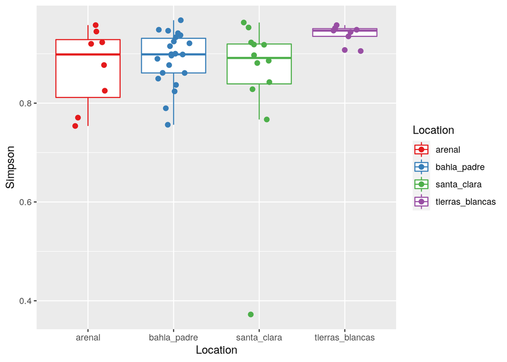

```r
JFFS.metaF %>%
  ggplot(aes(x=Location, y=Simpson, colour = Location)) +
  geom_boxplot(outlier.shape = NA) +
  geom_jitter(height = 0, size = 2, width = 0.2) +
  scale_colour_brewer(palette = "Set1")
```

**Figure 14:** Exloratory qqplot

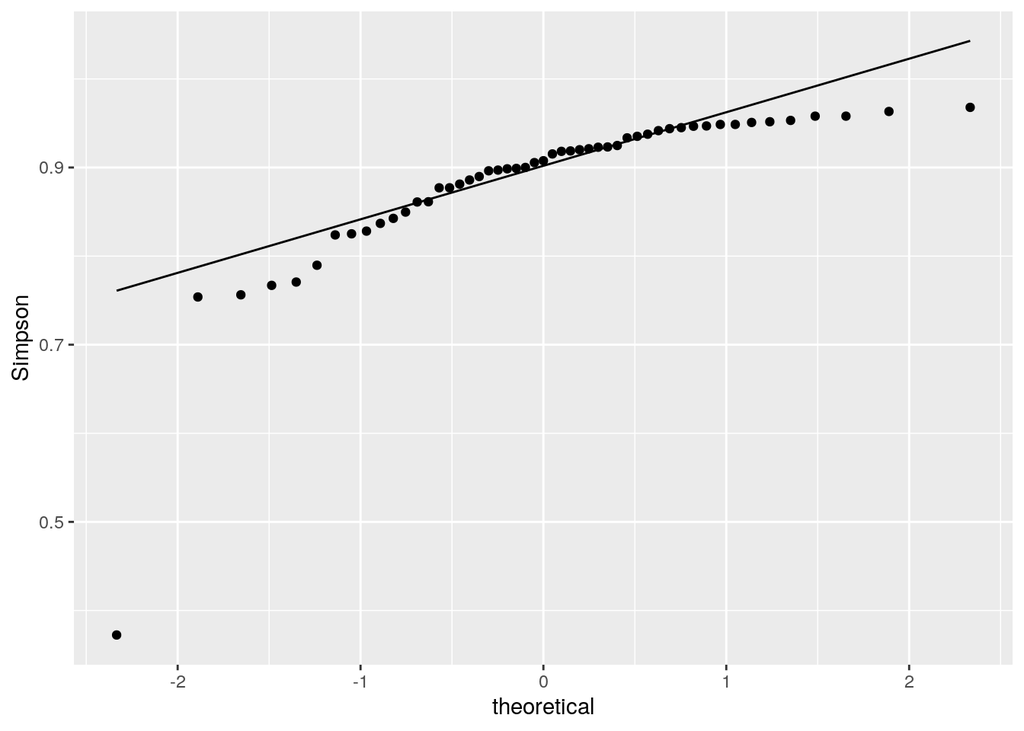

```r
JFFS.metaF %>%
  ggplot(aes(sample = Simpson)) +
  stat_qq() +
  stat_qq_line() +
  ylab("Simpson")
```

**Figure 15:** Exloratory qqplot per location

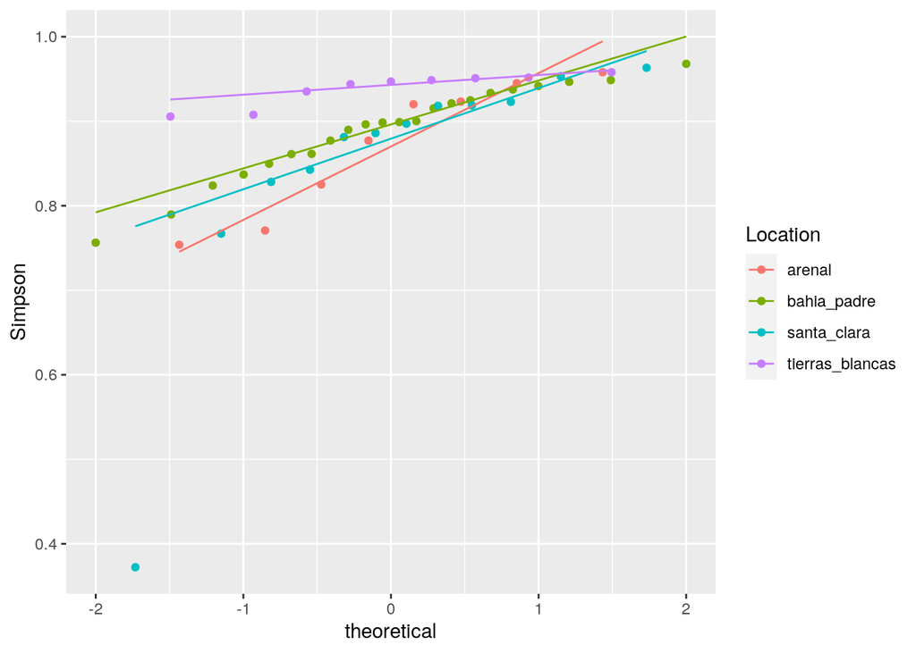

```r
JFFS.metaF %>%
  ggplot(aes(sample = Simpson, colour=Location)) +
  stat_qq() +
  stat_qq_line() +
  ylab("Simpson")
```

- Anova

```r
fit.Simpson <- lm(Simpson~Location, data=JFFS.metaF)
summary(fit.Simpson)
```

```
##
## Call:
## lm(formula = Simpson ~ Location, data = JFFS.metaF)
##
## Residuals:
##      Min       1Q   Median       3Q      Max
## -0.47357 -0.02864  0.00993  0.04983  0.11737
##
## Coefficients:
##                         Estimate Std. Error t value Pr(>|t|)
## (Intercept)              0.87163    0.03205  27.193   <2e-16 ***
## Locationbahia_padre      0.01822    0.03743   0.487    0.629
## Locationsanta_clara     -0.02575    0.04138  -0.622    0.537
## Locationtierras_blancas  0.06706    0.04405   1.522    0.135
## ---
## Signif. codes:  0 '***' 0.001 '**' 0.01 '*' 0.05 '.' 0.1 ' ' 1
##
## Residual standard error: 0.09066 on 47 degrees of freedom
## Multiple R-squared:  0.1069, Adjusted R-squared:  0.04993
## F-statistic: 1.876 on 3 and 47 DF,  p-value: 0.1466
```

- Checking assumption: Shapiro test

```r
JFFS.metaF %>%
  group_by(Location) %>%
  shapiro_test(Simpson)
```

```
## # A tibble: 4 x 4
##   Location        variable statistic        p
##   <fct>           <chr>        <dbl>    <dbl>
## 1 arenal          Simpson      0.891 0.240
## 2 bahia_padre     Simpson      0.941 0.204
## 3 santa_clara     Simpson      0.645 0.000261
## 4 tierras_blancas Simpson      0.802 0.0218
```

Santa Clara and Tierras Blancas did not met the normality assumption

- Checking assumption: Levene's test

```r
JFFS.metaF %>%
  levene_test(Simpson ~ Location)
```

```
## # A tibble: 1 x 4
##     df1   df2 statistic     p
##   <int> <int>     <dbl> <dbl>
## 1     3    47      1.72 0.176
```

Heteroscedaticity assumption was met

- Looking for outliers  
  Check for residuals. *Values with standardised residual > 3 will be considered outliers.*

```r
rstandard(fit.Simpson) -> st.residual.Simpson
st.residual.Simpson
```

```
##             1             2             3             4             5
## -0.3247468811  0.3537217315 -1.5078460482 -0.5975849731  0.6404607569
##             6             7             8             9            10
## -0.1441038690  0.8809517989  0.4923342007  0.1161466207  0.2255106417
##            11            12            13            14            15
##  0.2875119019 -0.3630789228  0.0600380884  0.1423230907  0.5845016915
##            16            17            18            19            20
##  0.1516945591  1.0179430220  0.3949593088 -1.1309242194  0.0980480634
##            21            22            23            24            25
## -0.7446261399  0.1153877668  0.0725665837 -0.3218887797 -0.3878728613
##            26            27            28            29            30
##  0.5713439582  0.0647853088 -1.1901547836  0.6081713670 -0.5481549159
##            31            32            33            34            35
## -0.4535947962  0.1030522014  1.3521415245  0.4611440728  0.0961175551
##            36            37            38            39            40
##  0.5899979854  0.8389296338 -5.4557418166  1.2358855551  0.4075980648
##            41            42            43            44            45
##  0.8335158662 -0.0378929560 -0.2036761216 -0.0408787715 -0.9091915648
##            46            47            48            49            50
##  0.8872897565 -0.0004328562  0.5390153601  0.6632371972  0.8649200490
##            51
## -1.3888540056
```

Same outlier.

- Anova (clean data)

```r
fit.Simpson <- lm(Simpson~Location, data=JFFS.metaFclean)
summary(fit.Simpson)
```

```
##
## Call:
## lm(formula = Simpson ~ Location, data = JFFS.metaFclean)
##
## Residuals:
##      Min       1Q   Median       3Q      Max
## -0.13356 -0.03047  0.00845  0.03473  0.08633
##
## Coefficients:
##                         Estimate Std. Error t value Pr(>|t|)
## (Intercept)              0.87163    0.01962  44.425   <2e-16 ***
## Locationbahia_padre      0.01822    0.02291   0.795   0.4306
## Locationsanta_clara      0.01730    0.02579   0.671   0.5057
## Locationtierras_blancas  0.06706    0.02697   2.487   0.0166 *
## ---
## Signif. codes:  0 '***' 0.001 '**' 0.01 '*' 0.05 '.' 0.1 ' ' 1
##
## Residual standard error: 0.05549 on 46 degrees of freedom
## Multiple R-squared:  0.1372, Adjusted R-squared:  0.08092
## F-statistic: 2.438 on 3 and 46 DF,  p-value: 0.0765
```

- Re-checking assumption: Shapiro test

```r
JFFS.metaFclean %>%
  group_by(Location) %>%
  shapiro_test(Simpson)
```

```
## # A tibble: 4 x 4
##   Location        variable statistic      p
##   <fct>           <chr>        <dbl>  <dbl>
## 1 arenal          Simpson      0.891 0.240
## 2 bahia_padre     Simpson      0.941 0.204
## 3 santa_clara     Simpson      0.939 0.514
## 4 tierras_blancas Simpson      0.802 0.0218
```

Normality assumption was not met for tierra blancas

- Re-checking assumption: Levene's test

```r
JFFS.metaFclean %>%
  levene_test(Simpson ~ Location)
```

```
## # A tibble: 1 x 4
##     df1   df2 statistic      p
##   <int> <int>     <dbl>  <dbl>
## 1     3    46      3.04 0.0382
```

Heteroscedasticity assumption was not met.

- Non-parametric test

```r
kruskal.test(JFFS.metaFclean$Simpson ~ JFFS.metaFclean$Location)
```

```
##
##  Kruskal-Wallis rank sum test
##
## data:  JFFS.metaFclean$Simpson by JFFS.metaFclean$Location
## Kruskal-Wallis chi-squared = 8.263, df = 3, p-value = 0.04088
```

The non-parametric test Kruskal-Wallis showed a significant difference between locations. Once more the trend seems to be consistent, but be aware the the heteroscedasticity assumption was not met.

- post hoc test

```r
DunnTest(JFFS.metaFclean$Simpson ~ JFFS.metaFclean$Location,
         method = "bonferroni")
```

```
##
##  Dunn's test of multiple comparisons using rank sums : bonferroni
##
##                             mean.rank.diff   pval
## bahia_padre-arenal               1.1136364 1.0000
## santa_clara-arenal               1.4318182 1.0000
## tierras_blancas-arenal          16.3611111 0.1254
## santa_clara-bahia_padre          0.3181818 1.0000
## tierras_blancas-bahia_padre     15.2474747 0.0492 *
## tierras_blancas-santa_clara     14.9292929 0.1362
## ---
## Signif. codes:  0 '***' 0.001 '**' 0.01 '*' 0.05 '.' 0.1 ' ' 1
```

## 3.2 Core Data

```r
coremetaF %>%
  group_by(Location) %>%
  get_summary_stats(Simpson, type = "mean_sd") %>%
  ungroup()
```

```
## # A tibble: 4 x 5
##   Location        variable     n  mean    sd
##   <fct>           <chr>    <dbl> <dbl> <dbl>
## 1 arenal          Simpson      8 0.833 0.09
## 2 bahia_padre     Simpson     22 0.845 0.064
## 3 santa_clara     Simpson     12 0.801 0.186
## 4 tierras_blancas Simpson      9 0.902 0.015
```

**Figure 16:** Exploratory boxplot

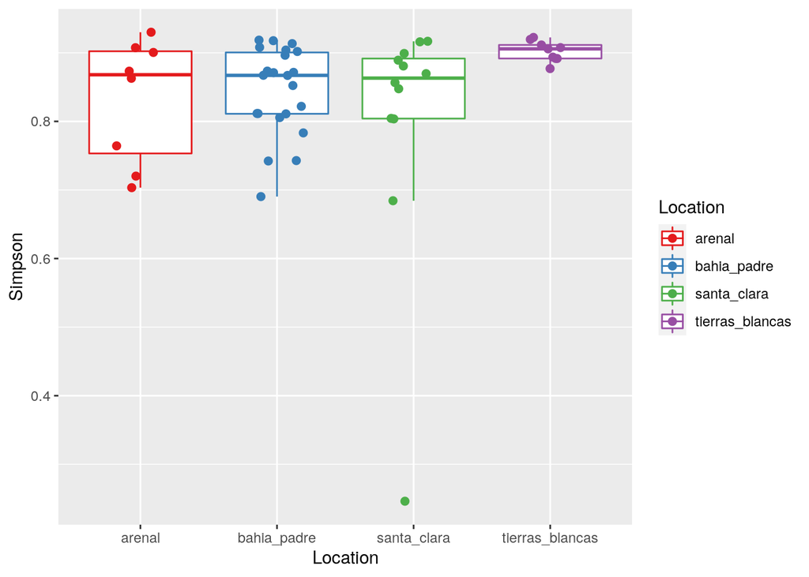

```r
coremetaF %>%
  ggplot(aes(x=Location, y=Simpson, colour = Location)) +
  geom_boxplot(outlier.shape = NA) +
  geom_jitter(height = 0, size = 2, width = 0.2) +
  scale_colour_brewer(palette = "Set1")
```

**Figure 17:** Exploratory qqplot

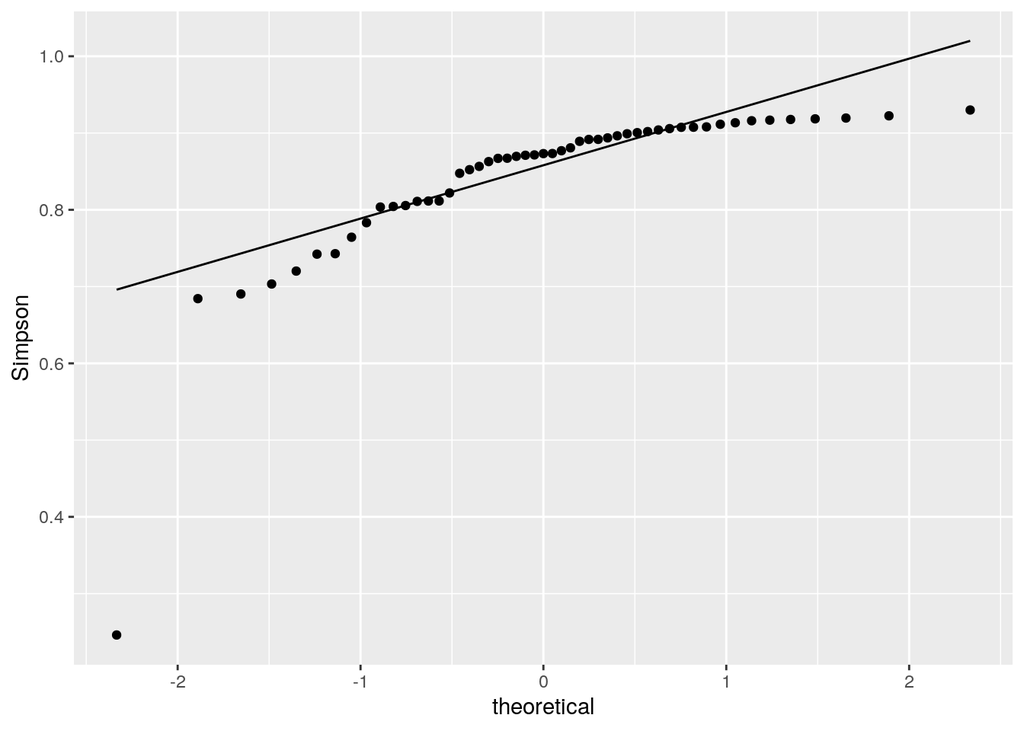

```r
coremetaF %>%
  ggplot(aes(sample = Simpson)) +
  stat_qq() +
  stat_qq_line() +
  ylab("Simpson")
```

**Figure 18:** Exploratory qqplot location

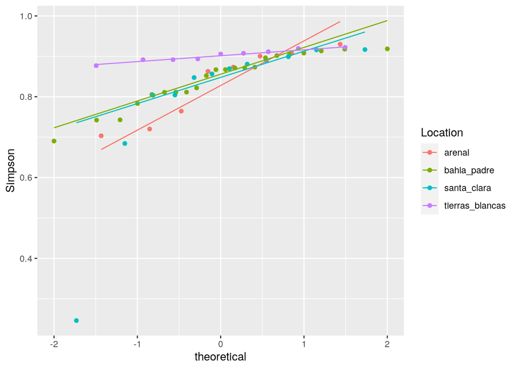

```r
coremetaF %>%
  ggplot(aes(sample = Simpson, colour=Location)) +
  stat_qq() +
  stat_qq_line() +
  ylab("Simpson")
```

- Anova

```r
fit.Simpson <- lm(Simpson~Location, data=coremetaF)
summary(fit.Simpson)
```

```
##
## Call:
## lm(formula = Simpson ~ Location, data = coremetaF)
##
## Residuals:
##      Min       1Q   Median       3Q      Max
## -0.55505 -0.02924  0.02011  0.06137  0.11565
##
## Coefficients:
##                         Estimate Std. Error t value Pr(>|t|)
## (Intercept)              0.83273    0.03741  22.262   <2e-16 ***
## Locationbahia_padre      0.01192    0.04368   0.273    0.786
## Locationsanta_clara     -0.03157    0.04829  -0.654    0.516
## Locationtierras_blancas  0.06959    0.05141   1.354    0.182
## ---
## Signif. codes:  0 '***' 0.001 '**' 0.01 '*' 0.05 '.' 0.1 ' ' 1
##
## Residual standard error: 0.1058 on 47 degrees of freedom
## Multiple R-squared:  0.09242,    Adjusted R-squared:  0.03449
## F-statistic: 1.595 on 3 and 47 DF,  p-value: 0.2031
```

- Checking assumption: Shapiro test

```r
coremetaF %>%
  group_by(Location) %>%
  shapiro_test(Simpson)
```

```
## # A tibble: 4 x 4
##   Location        variable statistic        p
##   <fct>           <chr>        <dbl>    <dbl>
## 1 arenal          Simpson      0.866 0.139
## 2 bahia_padre     Simpson      0.909 0.0462
## 3 santa_clara     Simpson      0.612 0.000136
## 4 tierras_blancas Simpson      0.953 0.722
```

Bahia el Padre and Santa Clara did not meet the normality assumption.

- Checking assumption: Levene's test

```r
coremetaF %>%
  levene_test(Simpson ~ Location)
```

```
## # A tibble: 1 x 4
##     df1   df2 statistic     p
##   <int> <int>     <dbl> <dbl>
## 1     3    47      1.49 0.229
```

Heteroscedaticity assumption was met.

- Looking for outliers Check for residuals *Values with standardised residual > 3 will be considered outliers.*

```r
rstandard(fit.Simpson) -> st.residual.Simpson
st.residual.Simpson
```

```
##           1           2           3           4           5           6
## -0.37833064  0.61307125 -1.49295014 -0.99081381  0.66517779 -0.32103436
##           7           8           9          10          11          12
##  0.70649137  0.50078134  0.09136442  0.17268428  0.21811491 -0.25417907
##          13          14          15          16          17          18
##  0.05291773 -0.10668816  0.07387193  0.03461405  0.98285469  0.57438297
##          19          20          21          22          23          24
## -0.98495682 -0.21989727 -0.32053479  0.25542625  0.25973202 -0.59438736
##          25          26          27          28          29          30
## -0.10591855  0.75510593  0.30391989 -1.13723983  0.40911974 -0.69143862
##          31          32          33          34          35          36
## -0.32586888  0.27731182  1.14169126  0.54690253  0.20161479  0.78557036
##          37          38          39          40          41          42
##  0.45796823 -5.47956430  1.13401613  0.67567671  0.96655693  0.03150425
##          43          44          45          46          47          48
##  0.02422828 -0.08640948 -1.15385948  0.86930910  0.21619124  0.55386023
##          49          50          51
##  0.71436096  0.68510074 -1.30742254
```

Same outlier detected.

- Anova (clean data)

```r
fit.Simpson <- lm(Simpson~Location, data=coremetaFclean)
summary(fit.Simpson)
```

```
##
## Call:
## lm(formula = Simpson ~ Location, data = coremetaFclean)
##
## Residuals:
##      Min       1Q   Median       3Q      Max
## -0.16734 -0.03317  0.01317  0.04571  0.09727
##
## Coefficients:
##                         Estimate Std. Error t value Pr(>|t|)
## (Intercept)              0.83273    0.02272  36.648   <2e-16 ***
## Locationbahia_padre      0.01192    0.02653   0.449   0.6553
## Locationsanta_clara      0.01889    0.02986   0.633   0.5301
## Locationtierras_blancas  0.06959    0.03123   2.228   0.0308 *
## ---
## Signif. codes:  0 '***' 0.001 '**' 0.01 '*' 0.05 '.' 0.1 ' ' 1
##
## Residual standard error: 0.06427 on 46 degrees of freedom
## Multiple R-squared:  0.1228, Adjusted R-squared:  0.06557
## F-statistic: 2.146 on 3 and 46 DF,  p-value: 0.1073
```

- Re-checking assumption: Shapiro test

```r
coremetaFclean %>%
  group_by(Location) %>%
  shapiro_test(Simpson)
```

```
## # A tibble: 4 x 4
##   Location        variable statistic      p
##   <fct>           <chr>        <dbl>  <dbl>
## 1 arenal          Simpson      0.866 0.139
## 2 bahia_padre     Simpson      0.909 0.0462
## 3 santa_clara     Simpson      0.843 0.0348
## 4 tierras_blancas Simpson      0.953 0.722
```

- Re-checking assumption: Levene's test

```r
coremetaFclean %>%
  levene_test(Simpson ~ Location)
```

```
## # A tibble: 1 x 4
##     df1   df2 statistic      p
##   <int> <int>     <dbl>  <dbl>
## 1     3    46      2.48 0.0725
```

Heteroscedasticity assumption was met

- Non-parametric test

```r
kruskal.test(coremetaFclean$Simpson ~ coremetaFclean$Location)
```

```
##
##  Kruskal-Wallis rank sum test
##
## data:  coremetaFclean$Simpson by coremetaFclean$Location
## Kruskal-Wallis chi-squared = 7.3799, df = 3, p-value = 0.06073
```

- post hoc test

```r
DunnTest(coremetaFclean$Simpson ~ coremetaFclean$Location,
         method = "bonferroni")
```

```
##
##  Dunn's test of multiple comparisons using rank sums : bonferroni
##
##                             mean.rank.diff   pval
## bahia_padre-arenal             -0.02272727 1.0000
## santa_clara-arenal              0.52272727 1.0000
## tierras_blancas-arenal         14.69444444 0.2282
## santa_clara-bahia_padre         0.54545455 1.0000
## tierras_blancas-bahia_padre    14.71717172 0.0644 .
## tierras_blancas-santa_clara    14.17171717 0.1833
## ---
## Signif. codes:  0 '***' 0.001 '**' 0.01 '*' 0.05 '.' 0.1 ' ' 1
```

# 4 Final visualisation

**Figure 19:**Comparison of three different alpha diversity indices between the four reproductive colonies in the Juan Fernandez archipelago. *In manuscript: Figure 3*

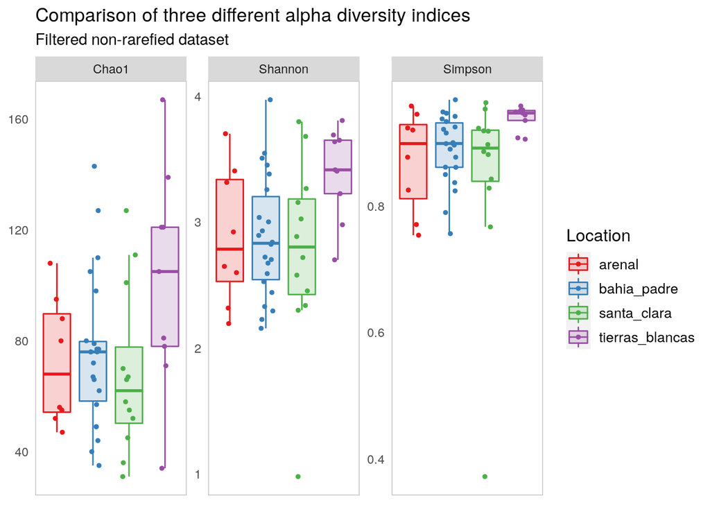

```r
#boxplot for the three indexes
#Gather the data
gather(JFFS.metaF, "index", "value", c("Chao1", "Shannon", "Simpson")) %>%
  dplyr::select('Location', 'index', 'value') -> JFFS.metaFlong


#lables
c("Chao1", "Shannon", "Simpson") -> index_lables


#PLOT
ggplot(JFFS.metaFlong,
       aes( x = Location,
            y = value,
            fill = Location,
            colour= Location)) +
  geom_boxplot(alpha = 0.2, outlier.shape = NA) +
  geom_jitter(height = 0,
              size = 1,
              width = 0.2) +
    facet_wrap(~ index,
               ncol = 3,
               scales = "free") +
  theme(axis.text.x = element_blank(),
        axis.ticks = element_blank(),
        axis.title.x = element_blank(),
        axis.title.y = element_blank(),
        panel.border = element_rect(colour = "grey",
                                    fill=NA),
        panel.background = element_blank(),
        legend.title = element_text(size = 12),
        legend.text = element_text(size = 10)) +
  scale_fill_brewer(palette = "Set1") +
  scale_colour_brewer(palette = "Set1") +
  labs(title = "Comparison of three different alpha diversity indices",
       subtitle = "Filtered non-rarefied dataset")
```

**Figure 20:** Comparison of three different alpha diversity indices between the four reproductive colonies in the Juan Fernandez archipelago. *In manuscript: Supplementary figure 2*

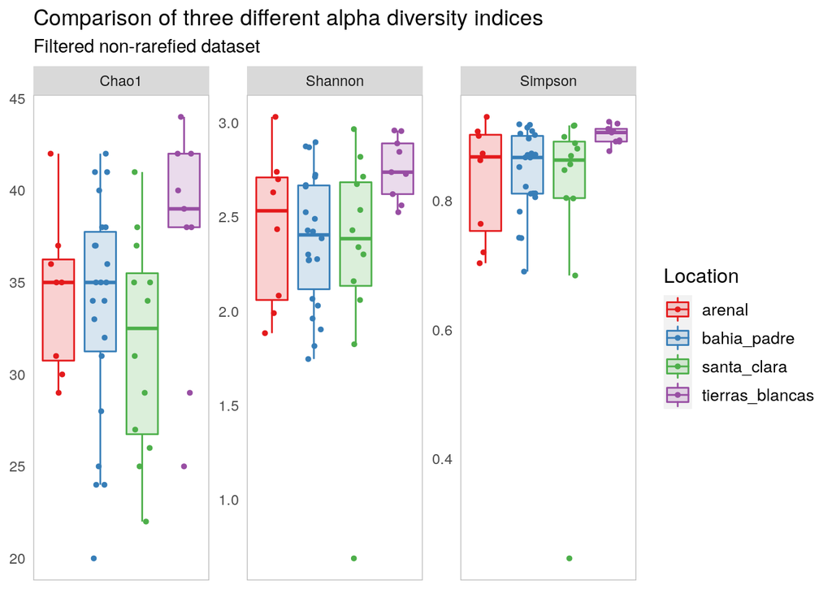

```r
#boxplot for the three indexes
#Gather the data
gather(coremetaF, "index", "value", c("Chao1", "Shannon", "Simpson")) %>%
  dplyr::select('Location', 'index', 'value') -> coremetaFlong


#lables
c("Chao1", "Shannon", "Simpson") -> index_lables


#PLOT
ggplot(coremetaFlong,
       aes( x = Location,
            y = value,
            fill = Location,
            colour= Location)) +
  geom_boxplot(alpha = 0.2, outlier.shape = NA) +
  geom_jitter(height = 0,
              size = 1,
              width = 0.2) +
    facet_wrap(~ index,
               ncol = 3,
               scales = "free") +
  theme(axis.text.x = element_blank(),
        axis.ticks = element_blank(),
        axis.title.x = element_blank(),
        axis.title.y = element_blank(),
        panel.border = element_rect(colour = "grey",
                                    fill=NA),
        panel.background = element_blank(),
        legend.title = element_text(size = 12),
        legend.text = element_text(size = 10)) +
  scale_fill_brewer(palette = "Set1") +
  scale_colour_brewer(palette = "Set1") +
  labs(title = "Comparison of three different alpha diversity indices",
       subtitle = "Filtered non-rarefied dataset")
```

For all three indices there was a consistent trend where samples collected from Tierras Blancas showed higher alpha diversity than the other three locations. This trend was also observed when using the core dataset. However, the differences in sample sizes as well as low sample numbers may have contributed to the lack of statistical significance in the many of the comparisons. The difference was more consistent with Shannon and Simpson. Both indices take in to account the relative abundance of each ASV. Location only explained a very small percentage of the alpha diversity variability.